# Tarea 2: Prediccion Promotores

1. Completar el codigo fuente del programa 1.1 para implementar el predictor de Kanhere y Bansal, justificando los valores de cutoff1 y cutoff2 de acuerdo con las figuras de su artículo. Es necesario comentar el codigo explicando sus cambios, por ejemplo con http://perldoc.perl.org/perlpod.html . Pueden usar el lenguaje de programacion que quieran, siempre que haya un compilador disponible.

El script se llama ‘script_D_E1_E2.pl’ y se encuentra en github.

2. Diseñar una figura donde se muestra gráficamente D, E1 y E2 para una posición n.

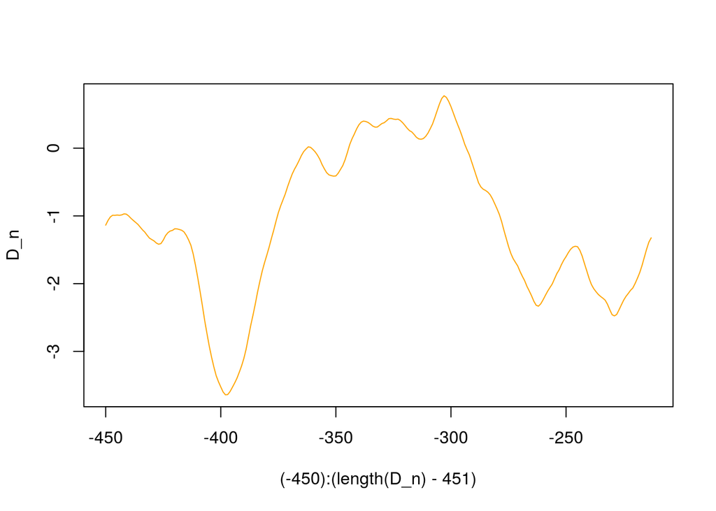

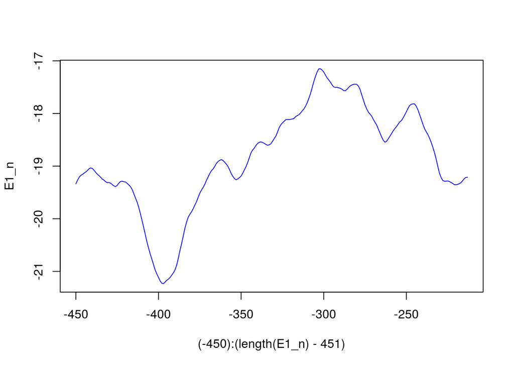

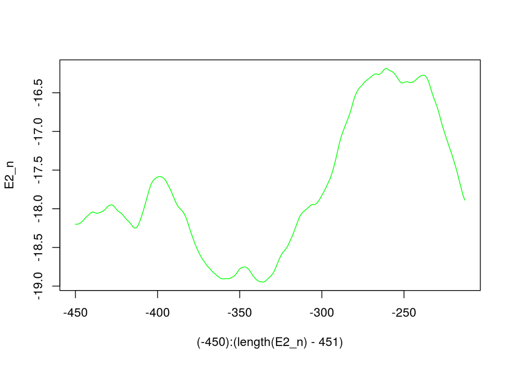

3. Predecir promotores en todas las secuencias del fichero K12_400_50_sites. De acuerdo a las distribuciones de D(n) y E1(n), el valor de corte para D se escogió de mayor 3, y el de E1 mayor a -15. Esto ya que se ofrece una buena sensitividad, y no hay muchas secuencias con valor de D(n) mayor a 3, además de que se busca mantener una buena precisión. Son los parámetros que dieron mejores resultados en el artículo.

| Id Secuencia | Nucleotidos Promotor | Nucleotidos Promotor |
| --- | --- | --- |
| b0077 | 215-229 |  |
| b0112 | 46-62 | 97-115 |
| b0116 | 135-169 |  |
| b0118 | 223-237 |  |
| b0365 | 129-139 |  |
| b0383 | 0-36 |  |
| b0388 | 197-237 |  |
| b0463 | 6-24 |  |
| b0584 | 174-200 |  |
| b0585 | 214-237 |  |
| b0592 | 12-45 | 133-154 |
| b0698 | 99-173 |  |
| b0781 | 189-201 |  |
| b0811 | 108-124 |  |
| b0827 | 201-237 |  |
| b0889 | 96-141 |  |
| b0894 | 153-237 |  |
| b0957 | 153-158 |  |
| b0971 | 235-237 |  |
| b0972 | 141-206 |  |
| b1040 | 166-177 |  |
| b1182 | 8-24 |  |

En la segunda y tercer columna se muestra el rango de nucleótidos que cumpieron con el cutoff. Hubo dos ocasiones en donde se predijeron dos promotores.

4. Graficar con que frecuencia se predicen promotores en el intervalo -400,50. Con un breve comentario de los resultados es suficiente. Se les ocurre una manera de validar sus resultados, y calcular la tasa de FPs, usando RSAT::matrix-scan?

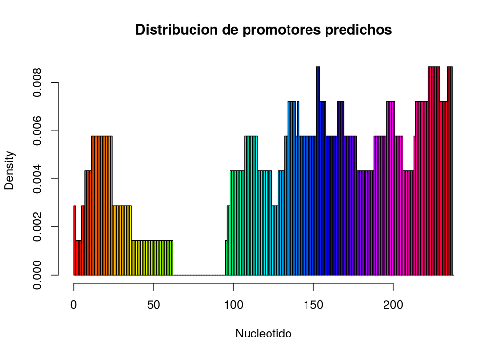

Hay un sesgo entre los promotores predichos, pues ninguno se encuentra en la region entre 60 y 100 nucleótidos (-390, -350 con respecto al gen). Los promotores se encuentran en la región -450 al -400 y del -350 al -200 , pero mayoritariamente en esta última región.

Podriamos validar los resultados utilizando matriz scan. Pondriamos la region de DNA de nuestra predicción junto con las matrices de promotores ya reportados, para ver si alinean. De esta manera, si tenemos alguna predicción que sea un falso positivo, deberíamos poder detectar este error al comparar con la secuencia de promotores ya establecidos.